# Practical Machine Learning - Predict The Manner of People Excercise Activity

Venkat Vasam

Augist 31, 2019

## Overview

Human Activity Recognition(HAR) measures people activity. There are several electromechanical devices (accelormeters) that provide HAR metrics by sensing either static or dynamic forces of acceleration. Gravity is a static force, and vibrations and movement are dynamic forces.

This report uses weight lifting excercise data collected from accelormeters of 6 participants. The accelormeters were used on on the belt, forearm, arm, and dumbell. The participants were asked to perform barbell lifts correctly and incorrectly in 5 different ways (set of 10 repetitions). The five different ways are: exactly according to the specification (Class A), throwing the elbows to the front (Class B), lifting the dumbbell only halfway (Class C), lowering the dumbbell only halfway (Class D) and throwing the hips to the front (Class E).

The outcome this report is prediction of the manner participants did the excercise. The quality of excerice is defined as Class A is correct way doing excercies and 4 other classes are common mistakes. The age of participants is 20-28 years, with a little weight lifting experience.

# Prediction Steps

The prediction process uses the the following steps to predict the efficieny of HAR activity

Question -> Input Data ->Features ->Alogritham -> Parameters ->evaluation

## Question :

The question of this pediction excercise : predict one of the 5 different ways that participants’s execrcise activity can be classified as based on the weight lifting excercise validation data set.

## Input Data :

The input data is avaliable from the following URLs:

The training data for this project is available here:

https://d396qusza40orc.cloudfront.net/predmachlearn/pml-training.csv

The test/validation data is available here:

https://d396qusza40orc.cloudfront.net/predmachlearn/pml-testing.csv

## Exploratory Data Analysis/Features :

```
The total number of rows/observations and columns/features of training data: 19622 160
```

```
The total number of rows/observations and columns/features of test/validation data: 20 160
```

[output not shown]

```
The feature in training but not in test/validation data set: classe
```

```
The feature in test/validation but not in training data set: problem_id
```

```
After removing near zero variance features, the total number of rows/observations and columns/features of training data: 19622 100
```

```
After removing features with more NA values, the total number of rows/observations and columns/features of training data: 19622 59
```

```
After removing features specific to individuals, the total number of rows/observations and columns/features of training data: 19622 52
```

Recursive feature selection process showed the following top 5 predictors:

Outer resampling method: Cross-Validated (10 fold, repeated 1 times)

Resampling performance over subset size:

Variables Accuracy Kappa AccuracySD KappaSD Selected 4 0.9584 0.9474 0.002431 0.003081  
8 0.9865 0.9830 0.003561 0.004504  
16 0.9930 0.9912 0.001577 0.001995  
51 0.9964 0.9954 0.001212 0.001533 *

The top 5 variables (out of 51): yaw_belt, magnet_dumbbell_z, pitch_belt, magnet_dumbbell_y, pitch_forearm

## Prediction

The process followed the following steps for predicting the outcome:

1. Define error rate.
2. Split training data into training and test data sets.
3. On the training data set pick relevant features.
4. On the training set pick prediction function.
5. Apply prediction function on the training data set.
6. Apply the prediction on validation data set.

The acceptable error rate for this prediction is less than 1 percent to make prediction 99 percentile correct. The cross validation is performed by splitting the given training data set into training/test sets. The model is created on the training set and evaluated on the test set. The cross-validation process will be repeated and average of the estimated errors will be calculated. The cross validation is used for picking variables to include in a model, type of prediction to use and the parameters in the prediction function. The cross validation also compares predictors.

The prediction considered the following three approaches:

1. Prediction with Classification tree
2. Prediction with Random Forest
3. Boosting with trees (gbm)

The manual observation of total predictors it seems the features with total_accel prefix for all the accelerometers will be a good predictor. The following feature plot and density plot shows our come classe versus total_accel predictors.

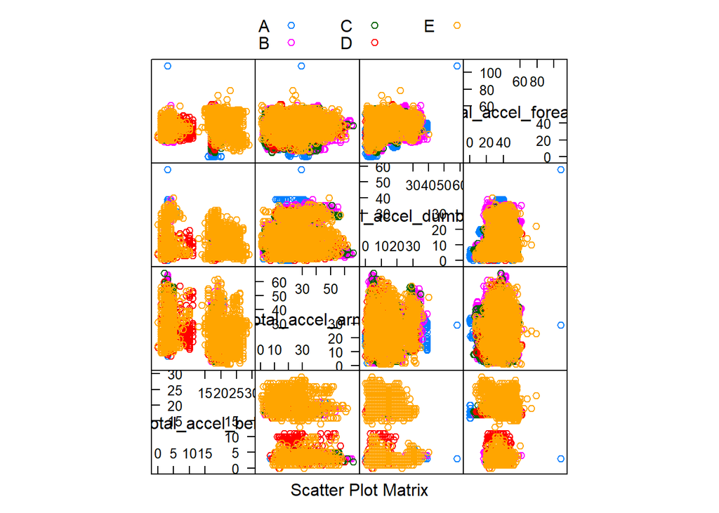

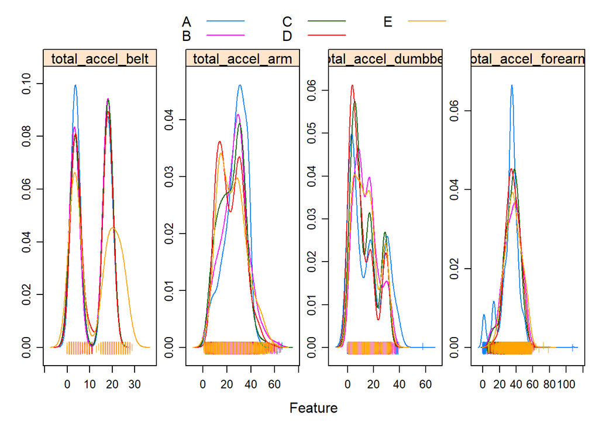

The total_accel_arm and total_accel_forearm features shows better distribution curve compared to all other features.

The following feature plot and density plot shows outcome classe versus top 5 predictors that recursive feature elimination process selected.

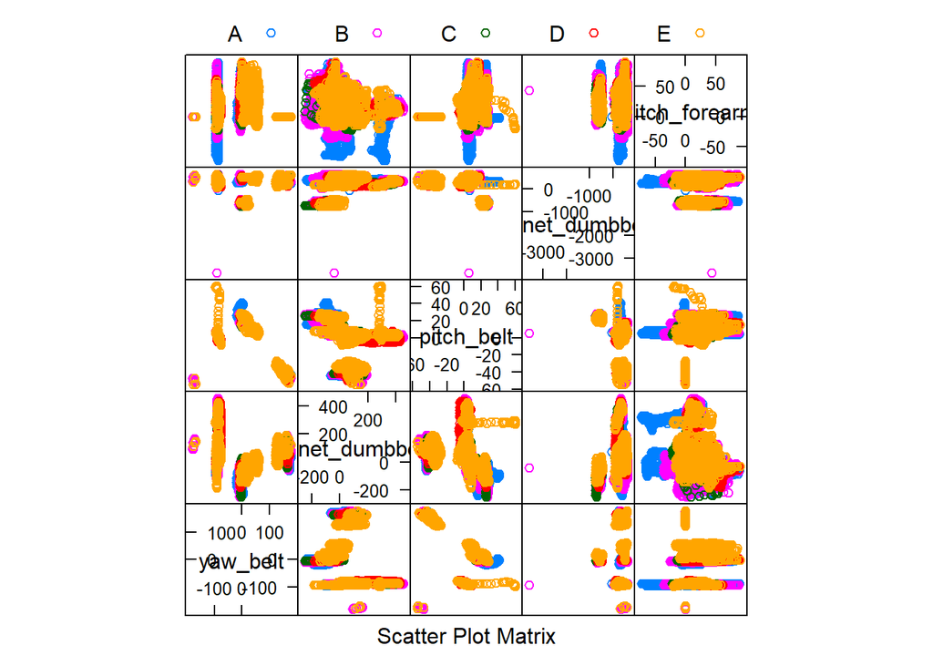

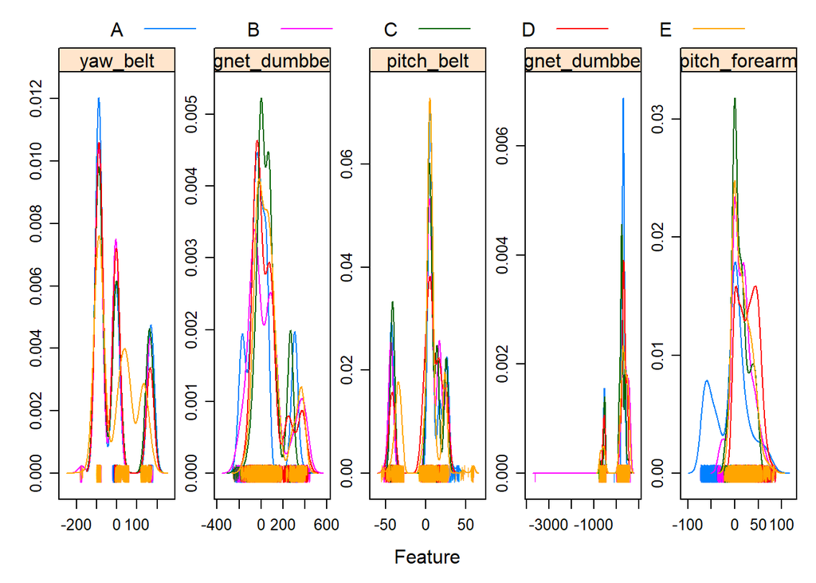

The pitch_forearm feature graph also shows better distribution curve.

## Prediction with Classification tree

The prediction with classification tree gives better performance in nonlinear settings. Iteratively splits variables into groups, evaluates homogeneity within each group and splits again if necessary

The following confusion matrix and plot shows the prediction with classification tree method.

```
Confusion Matrix and Statistics

          Reference
Prediction    A    B    C    D    E
         A 1260   28   75   29    3
         B  409  300  116  124    0
         C  397   31  370   57    0
         D  342  161  121  180    0
         E  208  182  133  114  264

Overall Statistics

               Accuracy : 0.4841
                 95% CI : (0.47, 0.4982)
    No Information Rate : 0.5334
    P-Value [Acc > NIR] : 1

                  Kappa : 0.3254

 Mcnemar's Test P-Value : <2e-16

Statistics by Class:

                     Class: A Class: B Class: C Class: D Class: E
Sensitivity            0.4817  0.42735  0.45399   0.3571  0.98876
Specificity            0.9410  0.84555  0.88139   0.8582  0.86263
Pos Pred Value         0.9032  0.31612  0.43275   0.2239  0.29301
Neg Pred Value         0.6136  0.89836  0.89010   0.9210  0.99925
Prevalence             0.5334  0.14315  0.16619   0.1028  0.05445
Detection Rate         0.2569  0.06117  0.07545   0.0367  0.05383
Detection Prevalence   0.2845  0.19352  0.17435   0.1639  0.18373
Balanced Accuracy      0.7113  0.63645  0.66769   0.6077  0.92570
```

[figure not shown]

The accuracy is 0.48 (48%) and out of sample error is .52(52%). So, the out of sample rate is so high.

The fancy plot shows the classification based on variables.

## Prediction with Random Forest

Accuracy will be good with Random Forest. Bootstrapping is performed at each split and multiple trees will be created to decide the final outcome.

```
Confusion Matrix and Statistics

          Reference
Prediction    A    B    C    D    E
         A 1395    0    0    0    0
         B   13  934    2    0    0
         C    0    7  847    1    0
         D    0    0    1  802    1
         E    0    0    1    0  900

Overall Statistics

               Accuracy : 0.9947
                 95% CI : (0.9922, 0.9965)
    No Information Rate : 0.2871
    P-Value [Acc > NIR] : < 2.2e-16

                  Kappa : 0.9933

 Mcnemar's Test P-Value : NA

Statistics by Class:

                     Class: A Class: B Class: C Class: D Class: E
Sensitivity            0.9908   0.9926   0.9953   0.9988   0.9989
Specificity            1.0000   0.9962   0.9980   0.9995   0.9998
Pos Pred Value         1.0000   0.9842   0.9906   0.9975   0.9989
Neg Pred Value         0.9963   0.9982   0.9990   0.9998   0.9998
Prevalence             0.2871   0.1919   0.1735   0.1637   0.1837
Detection Rate         0.2845   0.1905   0.1727   0.1635   0.1835
Detection Prevalence   0.2845   0.1935   0.1743   0.1639   0.1837
Balanced Accuracy      0.9954   0.9944   0.9967   0.9991   0.9993
```

The accuracy is 0.99 (99%) and out of sample error is .01 (1%). The out of sample error rate is 1%

## Boosting with trees (GBM)

By combining the weak predictors strong predictor will be derived.

```
Confusion Matrix and Statistics

          Reference
Prediction    A    B    C    D    E
         A 1370   15    9    1    0
         B   44  875   26    0    4
         C    0   23  814   12    6
         D    1    3   22  766   12
         E    2   11    7   10  871

Overall Statistics

               Accuracy : 0.9576
                 95% CI : (0.9516, 0.9631)
    No Information Rate : 0.2889
    P-Value [Acc > NIR] : < 2.2e-16

                  Kappa : 0.9463

 Mcnemar's Test P-Value : 0.0001296

Statistics by Class:

                     Class: A Class: B Class: C Class: D Class: E
Sensitivity            0.9668   0.9439   0.9271   0.9708   0.9754
Specificity            0.9928   0.9814   0.9898   0.9908   0.9925
Pos Pred Value         0.9821   0.9220   0.9520   0.9527   0.9667
Neg Pred Value         0.9866   0.9869   0.9842   0.9944   0.9945
Prevalence             0.2889   0.1890   0.1790   0.1609   0.1821
Detection Rate         0.2794   0.1784   0.1660   0.1562   0.1776
Detection Prevalence   0.2845   0.1935   0.1743   0.1639   0.1837
Balanced Accuracy      0.9798   0.9626   0.9585   0.9808   0.9839
```

The accuracy is 0.95 (95%) and out of sample error is .05(5%)

## Final prediction with test/validation data set

The random forest has less out of sample error so the following shows the prediction with random forest model on test/validation data set

```
 [1] B A B A A E D B A A B C B A E E A B B B
Levels: A B C D E
```

## References

1. The R source code for this prediction can be accessed using the following GitHub URL:

https://github.com/vvasamgit/coursera-pml/blob/gh-pages/pml-project-final.R

2. The RMD file for this report is available at:

https://github.com/vvasamgit/coursera-pml/blob/gh-pages/pml-project-final.Rmd

3. This report is based on the HAR data collected from the source: http://web.archive.org/web/20161224072740/http:/groupware.les.inf.puc-rio.br/har.
4. Accelerometers: https://learn.sparkfun.com/tutorials/accelerometer-basics/all

## APPENDIX - R Source Code

The following source code is given in the report for quick reference.

```r
suppressPackageStartupMessages(library(dplyr))
suppressPackageStartupMessages(library(dplyr))
suppressPackageStartupMessages(library(ggplot2))
suppressPackageStartupMessages(library("gridExtra"))
suppressPackageStartupMessages(library(caret))
suppressPackageStartupMessages(library(randomForest))
suppressPackageStartupMessages(library(RColorBrewer))
suppressPackageStartupMessages(library(rattle))
suppressPackageStartupMessages(library(htmltools))

#Set working directory
workdir<-"C:\\Wrksps\\dev\\DataScienceCE\\datasciencecoursera\\PracticalMachineLearning\\Project"
setwd(workdir)

trnsetFileName<-"pml-training.csv"
validtstsetFileName<-"pml-testing.csv"

dataUrlBase<-"https://d396qusza40orc.cloudfront.net/predmachlearn"

trnDataUrl<-paste(dataUrlBase,"/",trnsetFileName, sep="")

validtstDataUrl<-paste(dataUrlBase,"/",validtstsetFileName, sep="")


# Download file to local fie system

download.file(trnDataUrl,trnsetFileName)

download.file(validtstDataUrl,validtstsetFileName)

#Read the train, test/validation file contents to data frame

trnDataIn<-read.csv(trnsetFileName)

validtstDataIn<-read.csv(validtstsetFileName)

cat("The total number of rows/observations and columns/features of training data:",dim(trnDataIn)[1],dim(trnDataIn)[2],"\n")

cat("The total number of rows/observations and columns/features of test/validation data:",dim(validtstDataIn)[1],dim(validtstDataIn)[2],"\n")


vldtstFeatureNames<-names(validtstDataIn)

trnFeatureNames<-names(trnDataIn)

cat("Features:",trnFeatureNames)

head(trnDataIn)

trnFeaturesOnly<-setdiff(trnFeatureNames,vldtstFeatureNames)

cat("The feature in training but not in test/validation data set:",trnFeaturesOnly,"\n")

vldFeatursOnly<-setdiff(vldtstFeatureNames, trnFeatureNames)

cat("The feature in test/validation but not in training data set:",vldFeatursOnly,"\n")


#roll, pitch, yaw, total, kurtosis, skewness, max,min, amplitude, variance of total acceleration , average , standard
#deviation , gyros_x,gyros_y,gyros_z, acceleration_X,acceleration_Y,acceleration_Z, magnetitude_x,magnetitude_y,magnetitude_z for all the accelerometer postions
#belt, forearm, arm, and dumbell

#near zero variance

nZerov <- nearZeroVar(trnDataIn)

trnData1<-trnDataIn[,-nZerov]

cat("After removing near zero variance features, the total number of rows/observations and columns/features of training data:",dim(trnData1)[1],dim(trnData1)[2],"\n")


#NA values
naPercent    <- sapply(trnData1, function(x) mean(is.na(x))) > 0.95
trnDat2<-trnData1[,naPercent==FALSE]

cat("After removing features with more NA values, the total number of rows/observations and columns/features of training data:",dim(trnDat2)[1],dim(trnDat2)[2],"\n")

# Remove first 7 features specific to individuals and time stamps of excercise
trnDat<-trnDat2[,-c(1:7)]

cat("After removing features specific to individuals, the total number of rows/observations and columns/features of training data:",dim(trnDat)[1],dim(trnDat)[2],"\n")


outFeatureName<-c('classe')

trnFeatureName<-names(trnDat)

predictors<-setdiff(trnFeatureName, outFeatureName)

#rfe .. recursive feature elimination using rfe.. the following code is commented out becasue report generation taking long time. But while generating final report uncomment this #code.

#rfCtrl <- rfeControl(functions = rfFuncs,method = "repeatedcv",repeats = 1,verbose=TRUE,allowParallel = FALSE)

#trnDatProf <- rfe(trnDat[,predictors], trnDat[,outFeatureName], rfeControl = rfCtrl)

#cat(trnDatProf)

#seperate training data to train and test data sets based on classe factor variable

inTrain<-createDataPartition(y=trnDat$classe, p=0.75,list=FALSE)

training<-trnDat[inTrain,]

testing<-trnDat[-inTrain,]

trnames<-names(trnDat)

totl<-grepl("total_accel",trnames)

fnTotal<-trnames[which(totl==TRUE)]

featurePlot(x=training[, fnTotal], y=training$classe,plot="pairs",auto.key = list(columns = 3))

#featurePlot(x=training[, fnTotal], y=training$classe,plot="ellipse",auto.key = list(columns = 3))

featurePlot(x=training[, fnTotal], y=training$classe,plot="density",
            scales = list(x = list(relation="free"),
                          y = list(relation="free")),
            adjust = 1.5,
            pch = "|",
            layout = c(4, 1),
            auto.key = list(columns = 3))

rfeTop5<-c("yaw_belt", "magnet_dumbbell_z", "pitch_belt", "magnet_dumbbell_y", "pitch_forearm")

#rfeTop5<-trnDatProf$variables$var[1:5]

featurePlot(x=training[, rfeTop5], y=training$classe,plot="pairs",auto.key = list(columns = 5))

featurePlot(x=training[, rfeTop5], y=training$classe,plot="density",
            scales = list(x = list(relation="free"),
                          y = list(relation="free")),
            adjust = 1.5,
            pch = "|",
            layout = c(5, 1),
            auto.key = list(columns = 5))

# Classification tree

trControl <- trainControl(method="cv", number=5,verboseIter=FALSE,allowParallel = FALSE)

modelCLT <- train(classe~., data=training, method="rpart", trControl=trControl)

trainpred <- predict(modelCLT,newdata=testing)

#qplot(trainpred, classe, data=testing, xlab="predicted", ylab="Actual")

confMatCT <- confusionMatrix(testing$classe,trainpred)

confMatCT

fancyRpartPlot(modelCLT$finalModel)


#Random forest

controlRF <- trainControl(method="cv", number=3, verboseIter=FALSE,allowParallel = FALSE)

modelRF <- train(classe~., data=training, method="rf", trControl=controlRF, verbose=FALSE)

trainpredRF <- predict(modelRF,newdata=testing)

confMatRF <- confusionMatrix(testing$classe,trainpredRF)

confMatRF

#Boosting with RBM
modelGBM <- train(classe~., data=training, method="gbm", trControl=controlRF, verbose=FALSE)

trainpredGBM <- predict(modelGBM,newdata=testing)

confMatGBM <- confusionMatrix(testing$classe,trainpredGBM)

confMatGBM


#Final predtiction with validation data set

FinalTestPred <- predict(modelRF,newdata=validtstDataIn)

FinalTestPred
```